# Exploratory Analysis

## Movie Stars to 5 Stars: Actor Credits as Indicators of IMDb Score

### Authors

- Harry Fung
- Yosup Cho
- Hoda Ayad
- Brian Kim

### Date

Spring 2023

### Abstract

Having big names in the cast has always been a key marketing tactic for movies and TV shows alike, but does this strategy actually work? We intend to use the metadata of the shows and movies published on Netflix as of July 2022 to determine whether the major actor(s) credited in a piece of media is a significant indicator of a higher IMDb score as a representation of general reception. Considering there are many different contributing factors to IMDb scores, we will also take into account the number of votes on IMDb, the release year, and the maturity rating of the work to compare the impact on reception.

### Keywords

Entertainment, Ratings, Movies, Shows, Netflix, IMDB ratings

### Introduction

For this final project, our group intends to determine whether the actors shown in Netflix movies/shows serve as a reliable indicator of the show/movie’s ratings. We want to see whether there is a direct relationship between the actors used in the shows/movies, and the ratings that the movies/shows receive after its initial release. It is important that we answer this question because of the value our project results can hold for streaming companies and film/show development firms in general, as there have been instances where the actors used did not make up for the low ratings the film/show received. Although it is important that good actors are used to make a good film, we want to see whether using famous actors boost the ratings the show/movie receives compared to using mediocre or lesser-known ones. In order to determine this, our group seeks to answer the following (but not limited to) possible research questions:

What role have actors played in the overall success of a movie? What is the relationship between the actors used in Netflix movies/shows and the third-party ratings the movies/show receives (e.g. Rotten Tomato, IMDb)? Has the choice in actors portrayed in Netflix shows/movies impacted the ratings its viewers give it?

### Related Work

Our group project intends to explore the relationship between the actors casted in a Netflix movie/film and the overall ratings it receives after its initial release. Specifically, as stated in Part 1, we hope to determine whether the actors the movie/show casts is a reliable indicator in determining the overall rating of the show/movie. Below is a couple articles that discuss some films that had great casts, but terrible execution in the movie/show production (e.g. terrible script writing). For example, the Super Mario Bros. Movie (2023) has received mixed reviews because of things such as the execution of the film production. The same applies for the Cats movie discussed in a separate article, but the overall criticism and ratings the film received was consistently negative. What is common amongst both films is that they had an impressive cast, such as Chris Pratt voicing Mario in the Super Mario Bros. Movie and Idris Elba in the film Cats, but poor reviews and ratings from third-party companies like Rotten Tomatoes and IMDb. But whether the casts used in these movies serve as a reliable indicator of why the films were rated poorly remains a question our group intends on answering.

### The Dataset

> Where did you find the data? Please include a link to the data source

https://www.kaggle.com/datasets/victorsoeiro/netflix-tv-shows-and-movies?select=titles.csv

> Who collected the data?

Victor Soeiro

> How was the data collected or generated?

All data was collected utilizing the website JustWatch website which provides what streaming services has what shows or movies, IMDB rating, genre, runtime, age restriction, synopsis, and the cast. The atuhor states that the JustWatch website uses ajax to consume their API using GraphQL queries. The data returns as a JSON file. To get the data they need, they used a request package. They created a reference code for the streaming service Netflix to pass it as a GraphQL variable. The website’s API uses only one endpoint to get the queries. So, the author changed the parameters and the query to collect the streamings data. The website prevents a robot to get their data without specifying a User-Agent. To bypass, they created request headers. They then created post data and manipulated it to specify which streaming service it will get the data from. Because some streamings have over 3k movies and shows, the query only returns a total of 1960 results, which is not enough to collect all data. The author used the released year filter to create a cluster of items with below 1960 items. They created a loop function to get all titles available on a given streaming service. The returned data the author got was well formatted but was nested. They parse the data to a unique dictionary containing the correctly fields names. With all the functions defined, they group together to get all titles available on a streaming. Finally, created a function to get all titles from all the streaming services.

> Why was the data collected?

The data set was collected as a web scrapping project. The author wanted to analyze data in fields that they were interested in such as movies, shows, games, and anime.

> How many observations (rows) are in your data?

For the credits data set, there are 54314 unique observations. For the movies data set, there are 5850 unique observations.

> How many features (columns) are in the data?

There are a total 20 columns. For the credits data set, there are 5 columns. For the movies data set, there are 15 columns.

> What, if any, ethical questions or questions of power do you need to consider when working with this data?

There seems to be no ethical questions or questions of power to consider when working with the data.

> What are possible limitations or problems with this data? (at least 200 words)

One possible limitation with the data set is incompleteness. The dataset may not contain all of the titles available on Netflix, as it is based on a web-scraping process that may have missed certain titles or not captured all of the relevant information for each title. Another limitation might be accuracy. The information provided for each title, such as the release year, genre, and rating, may not always be accurate or up-to-date. Additionally, there may be errors or inconsistencies in the data due to the web-scraping process. In addition, language may be another limitation. Since the dataset is primarily focused on content available in English, it may limit its usefulness for analyzing Netflix’s offerings in non-English-speaking countries. The dataset does not include a lot of metadata about each title, such as plot summaries, which could limit the types of analyses that can be performed. There may also be some bias in the data set as well. It may be biased towards certain types of content or genres, depending on the web-scraping process used to collect the data. Finally, the lack of context may deem a problem. The dataset does not provide any context about how Netflix categorizes or recommends content to users, which could limit the usefulness of the data for understanding how Netflix’s recommendation algorithm works.

5. Limitations & Challenges >What challenges or limitations might you need to address with your project idea more broadly? Briefly discuss. (at least 150 words)

Our biggest challenge is having to data clean and preprocess. The dataset may contain missing or incorrect values, duplicates, and other data quality issues that need to be addressed before you can use the data for analysis. So, our team will need to spend time cleaning and preprocessing the data to ensure that the dataset is accurate and usable.

A slight problem may be that the dataset may have some sampling bias. It could be biased towards a certain type of content or genre that could affect the results of our analysis. With the lack of any titles that do not include English, it could potentially affect the scope of our project.

In addition, any findings, or insights we gain from the analysis of the dataset should be carefully interpreted and not over-generalized beyond the scope of the dataset. We will be considering limitations of the data when drawing conclusions and making recommendations based on our analysis.

### Implications

There are several stakeholders in our analysis of the correlation between an actor and their average movie rating. For instance movie studio producers may potentially wish to select for a certain role depending on how well said actor is regarded by the audience, judging on how well their previous movies were received. While this is great for studios to ensure that their investment is stable, it also runs the risk of improper casting of actors in an attempt to minimize potential risks. Actors would also likely wish to know their general movie ratings and reflect on their movie choices. In real life movie casting is based on many factors, such as an actor’s experience and the character played, while our analysis only look at the correlation between actor and rating. This runs the risk of oversimplifying movie reception to only being impacted by the actors involved, when in reality it is more complex than such.

### Limitations & Challenges

Our biggest challenge is having to data clean and preprocess. The dataset may contain missing or incorrect values, duplicates, and other data quality issues that need to be addressed before you can use the data for analysis. So, our team will need to spend time cleaning and preprocessing the data to ensure that the dataset is accurate and usable.

A slight problem may be that the dataset may have some sampling bias. It could be biased towards a certain type of content or genre that could affect the results of our analysis. With the lack of any titles that do not include English, it could potentially affect the scope of our project.

In addition, any findings, or insights we gain from the analysis of the dataset should be carefully interpreted and not over-generalized beyond the scope of the dataset. We will be considering limitations of the data when drawing conclusions and making recommendations based on our analysis.

Acknowledgements

At the moment we have nobody we wish to acknowledge as we are still in the early stages of our research. However we would like to thank Victor Soeiro for collecting our data, as well as Kaggle for hosting it.

### Summary Information

One of the values we calculated/found was movies with the highest IMDb scores by year. We identified the movies with the highest IMDb scores for each year. The dataset was grouped by release year, and for each year, we filtered the movie(s) with the maximum IMDb score. The results provide the release year, movie title, and corresponding IMDb score for each of these top-rated movies. Our team believed that it was important to see which movies had the highest ratings each year and how their scores compared with other highly rated IMDb movies.

We also determined the actors who appeared in the movie with the highest IMDb score. By finding the maximum IMDb score, we filtered the movies with that score. We then extracted the unique names of the actors from these top-rated movies. We found out that actors Bryan Cranston, Aaron Paul, Anna Gunn, Dean Norris, Jonathan Banks, Bob Odenkirk, Betsy Brandt, and RJ Mitte were actors in the highest-rated IMDb movie/series, Breaking Bad (2008).

Additionally, we analyzed the relationship between age certification/restriction and IMDb scores for movies. By grouping movie title and age certification, we calculated the average IMDb score for each combination. The results show the movie titles, their respective age certifications, and the corresponding average IMDb scores. The list is arranged in descending order based on IMDb scores.

Lastly, we identified the movie that received the most IMDb votes. The movie with the most IMDb votes provides valuable information about audience engagement, popularity, and industry trends. It has implications for decision-making, marketing, and understanding the preferences of moviegoers, making it an important metric to consider in the film industry. We found that the movie Inception had the highest number of IMDb votes.

### Aggregate Table

Our table shows the count of unique movies released in each year. It gives an overview of the variety and quantity of movies produced in different years. In addition, the table also has the average IMDb score for each year, which provides an indication of the overall quality or reception of movies in a particular year. It also includes the average number of votes for each year by distinct movies. This helps indicate the level of audience engagement and popularity of movies in different years. Finally the last column the highest rated movie of each year. It highlights the standout film that received the highest IMDb score among the distinct movies released in a specific year.

By examining these aggregate metrics, one can gain insights into trends and patterns in the movie industry over time. The table allows for comparisons between different years, showcasing variations in the number of movies, average scores, and audience engagement. It helps to identify exceptional movies and understand how they contribute to the overall landscape of film ratings.

| Release Year | Number of Distinct Movies | Average IMDb Score | Average IMDb Votes | Highest Rated Movie |
| --- | --- | --- | --- | --- |
| 1969 | 2 | 8.45 | 37691 | Monty Python’s Flying Circus |
| 1985 | 1 | 8.00 | 6399 | Waiting for the Hearse |
| 1967 | 2 | 7.70 | 92355 | The Dirty Dozen |
| 1971 | 1 | 7.70 | 155051 | Dirty Harry |
| 1963 | 1 | 7.60 | 2508 | Saladin the Victorious |
| 1958 | 1 | 7.50 | 4471 | Cairo Station |
| 1961 | 1 | 7.50 | 50748 | The Guns of Navarone |
| 1977 | 1 | 7.50 | 2460 | Hitler: A Career |
| 1954 | 2 | 7.45 | 21854 | White Christmas |
| 1972 | 3 | 7.33 | 36747 | Monty Python’s Fliegender Zirkus |
| 1966 | 1 | 7.30 | 16446 | The Professionals |
| 1975 | 2 | 7.30 | 267297 | Monty Python and the Holy Grail |
| 2000 | 11 | 7.28 | 129553 | Okupas |
| 1989 | 12 | 7.24 | 75237 | Seinfeld |
| 2006 | 44 | 7.20 | 106921 | DEATH NOTE |
| 2002 | 19 | 7.19 | 97274 | Still Game |
| 1979 | 5 | 7.12 | 80501 | Richard Pryor: Live in Concert |
| 1998 | 22 | 7.10 | 31791 | Cowboy Bebop |
| 1982 | 6 | 7.07 | 8889 | Monty Python Live at the Hollywood Bowl |
| 2001 | 19 | 7.07 | 50108 | Trailer Park Boys |
| 1995 | 10 | 7.02 | 193937 | Se7en |
| 1993 | 14 | 6.95 | 34893 | Bill Hicks: Revelations |
| 1994 | 16 | 6.94 | 234377 | Forrest Gump |
| 1990 | 7 | 6.93 | 183745 | GoodFellas |
| 2003 | 30 | 6.92 | 99509 | Chappelle’s Show |
| 1996 | 7 | 6.91 | 79199 | Avvai Shanmugi |
| 1999 | 13 | 6.90 | 62908 | One Piece |
| 1997 | 16 | 6.89 | 182277 | Stargate SG-1 |
| 1984 | 6 | 6.88 | 118385 | Once Upon a Time in America |
| 2010 | 60 | 6.83 | 93268 | Inception |
| 2004 | 37 | 6.82 | 85073 | Black Friday |
| 2014 | 144 | 6.82 | 37598 | NA |
| 2012 | 101 | 6.76 | 76800 | Call the Midwife |
| 2009 | 58 | 6.74 | 54185 | Midnight Diner |
| 2011 | 79 | 6.73 | 47394 | Hunter x Hunter |
| 1987 | 6 | 6.72 | 125318 | Full Metal Jacket |
| 2008 | 58 | 6.71 | 92623 | Breaking Bad |
| 1956 | 1 | 6.70 | 610 | Dark Waters |
| 2007 | 44 | 6.68 | 62006 | Heartland |
| 1976 | 3 | 6.67 | 269792 | Taxi Driver |
| 2015 | 201 | 6.66 | 30782 | Reply 1988 |
| 1959 | 1 | 6.60 | 78 | Ujala |
| 1983 | 4 | 6.60 | 21381 | Christine |
| 2013 | 123 | 6.60 | 47829 | Attack on Titan |
| 2016 | 347 | 6.59 | 20199 | Leah Remini: Scientology and the Aftermath |
| 2019 | 775 | 6.51 | 12092 | NA |
| 1974 | 1 | 6.50 | 237 | Manoranjan |
| 1981 | 3 | 6.50 | 4448 | Danger Mouse |
| 2017 | 537 | 6.50 | 17542 | NA |
| 2018 | 715 | 6.50 | 10457 | My Mister |
| 2005 | 30 | 6.43 | 69462 | Avatar: The Last Airbender |
| 1960 | 1 | 6.40 | 84 | Singapore |
| 2021 | 716 | 6.30 | 10413 | Arcane |
| 2020 | 743 | 6.29 | 10505 | The Last Dance |
| 1986 | 4 | 6.25 | 3719 | Adam: His Song Continues |
| 2022 | 347 | 6.20 | 6685 | NA |
| 1988 | 7 | 6.00 | 535 | Mobile Suit Gundam: Char’s Counterattack |
| 1991 | 12 | 5.99 | 9501 | NA |
| 1992 | 3 | 5.50 | 34739 | A River Runs Through It |
| 1980 | 3 | 5.23 | 23316 | Whispers |
| 1973 | 1 | 5.10 | 41 | Khoon Khoon |
| 1978 | 1 | 4.40 | 35 | Bandie |

### Top 10 Credited Contributors based on Average IMDb Score

Credited contributors on IMDb are not given a rating the way that properties are. To create a pseudo-score for each one, we calculated the average IMDb score for all of the movies or shows that they are credited in. To eliminate over-representation of contributors that appear in only one piece of media, only contributors that appear in over 5 piece of media according to IMDb were considered.

It’s interesting to see that 5 out of the 10 top credited contributors (Carol Cleveland, Eric Idle, Terry Gilliam, Terry Jones, and Graham Chapman) were all involved in the British comedy troupe “Monty Python.” The range of IMDb scores in the top 10 also fall within a very narrow margin. It’s also interesting to see that multiple nationalities are represented in the top 10 including American, British, Japanese, and Korean contributors.

[figure not shown]

### Age certification proportion in movies and TVs during 2000-2023

This chart shows the distribution of age rating and their relative proportion to each other in the years between 2000-2023. We choose this graph as we wanted to see how trend in the change in age ratings for movies and TV shows in recent years. It shows that in recent years, the proportion of content created for children and teens have decreased, compared to adult and unrated content.

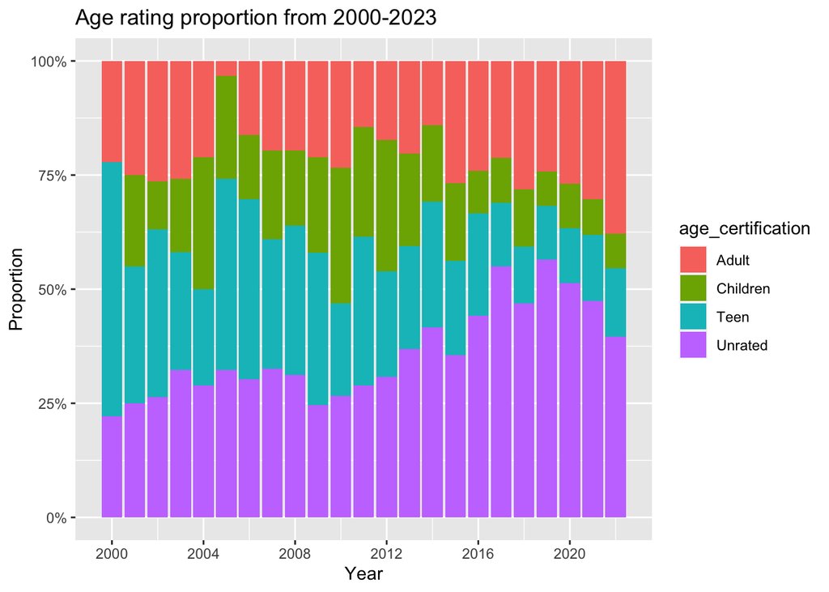

### Number of Shows and Films Released from 2000 to 2022

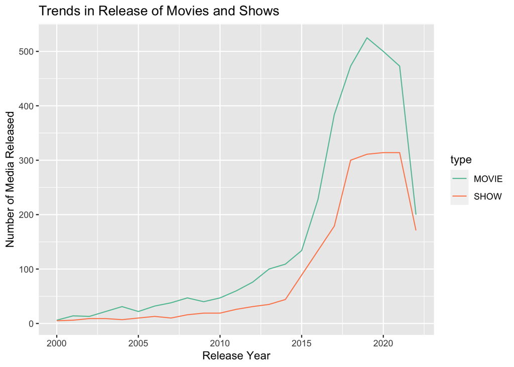